# Relación entre los atributos de los Pokémon

Marina Torres, Marcelino Cabrera

## Introducción

Pokémon es un juego desarrollado por The Pokémon Company, consorcio japonés compuesto por Nintendo, Game Freak y Creatures, en el que los jugadores tienen dos objetivos principales: coleccionar Pokémon y conseguir medallas de gimnasio como misiones para terminar la historia principal del juego.

Para conseguir ambos objetivos es necesario elegir un buen equipo de Pokémon ya que la forma principal de obtener los Pokémon es capturarlos después de debilitarlos en una batalla y para ganar las medallas necesitaremos derrotar en combate al jefe del gimnasio.

Para elegir nuestro equipo campeón debemos conocer las fortalezas y debilidades de cada uno de los Pokémon ya que existen interrelaciones entre las distintas características que pueden beneficiar o perjudicar durante los combates.

Cada uno de los Pokémon tiene una gran cantidad de atributos (Sanchez-Ante 2013) que los diferencian a uno de otro. Nosotros vamos a realizar nuestro análisis utilizando los atributos base que determinan la fuerza del Pokémon.

## Los datos

Veamos la estructura de los datos visualizando las 4 primeras filas.

```
##    id      Name   Type Total HP Attack Defense Sp_Attack Sp_Defense Speed
## 1 001 Bulbasaur  GRASS   318 45     49      49        65         65    45
## 2 001 Bulbasaur POISON   318 45     49      49        65         65    45
## 3 002   Ivysaur  GRASS   405 60     62      63        80         80    60
## 4 002   Ivysaur POISON   405 60     62      63        80         80    60
```

## Estudio

Iniciamos el estudio de los atributos viendo una relación general entre ellos.

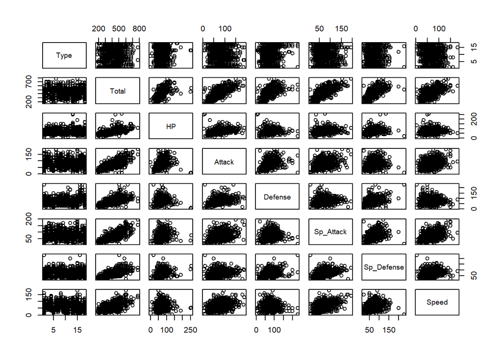

Veamos la correlación entre los distintos atributos de tipo numérico (Total, HP, Attack, Defense, Special.Attack, Special.Defense y Speed).

```
##            Total   HP Attack Defense Sp_Attack Sp_Defense Speed
## Total       1.00 0.65   0.73    0.60      0.74       0.70  0.58
## HP          0.65 1.00   0.46    0.24      0.39       0.37  0.21
## Attack      0.73 0.46   1.00    0.42      0.37       0.22  0.38
## Defense     0.60 0.24   0.42    1.00      0.18       0.51  0.01
## Sp_Attack   0.74 0.39   0.37    0.18      1.00       0.48  0.49
## Sp_Defense  0.70 0.37   0.22    0.51      0.48       1.00  0.25
## Speed       0.58 0.21   0.38    0.01      0.49       0.25  1.00
```

Podemos representar esta misma información en un correlograma donde las correlaciones positivas se muestran en azul y las correlaciones negativas en rojo. La intensidad del color y el tamaño del círculo son proporcionales a los coeficientes de correlación.

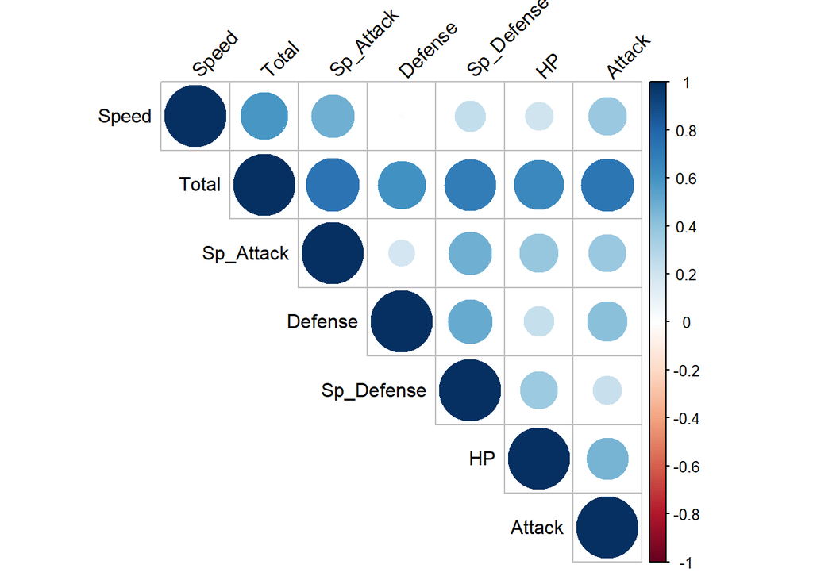

Podemos ver como no hay correlación entre los atributos Defense y Speed y que la variable Total es la única que tiene correlación con todas las demás ya que depende directamente de ellas. Otras correlaciones significativas (aunque menores) son Speed-Special.Attack, Special.Attack-Special.Defense, Defense-Special.Defense y Hp-Attack.

Veamos todos los atributos de todos los Pokémon según el tipo.

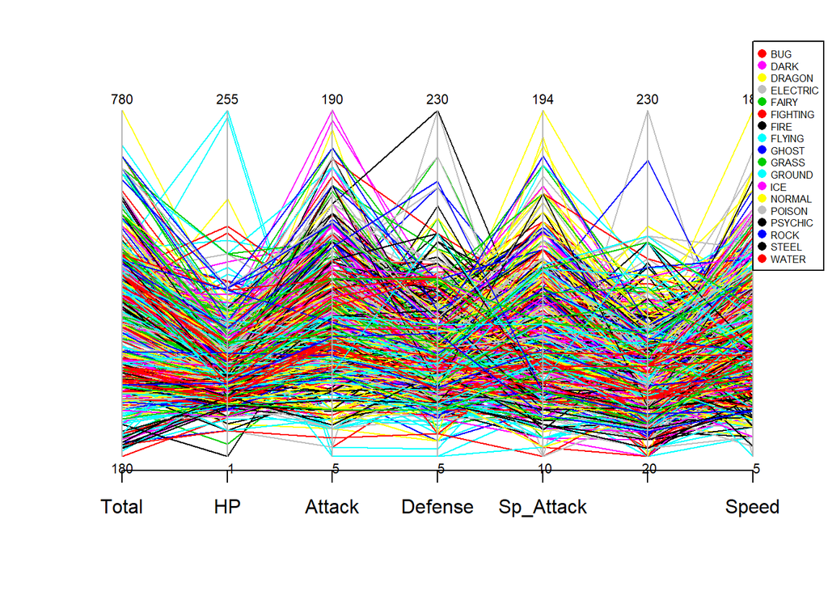

Comprobemos si para distintos tipos de Pokémon la relación entre atributos es diferente.

En primer lugar, obtenemos los tipos de Pokémon y a continuación calculamos la correlación entre sus atributos

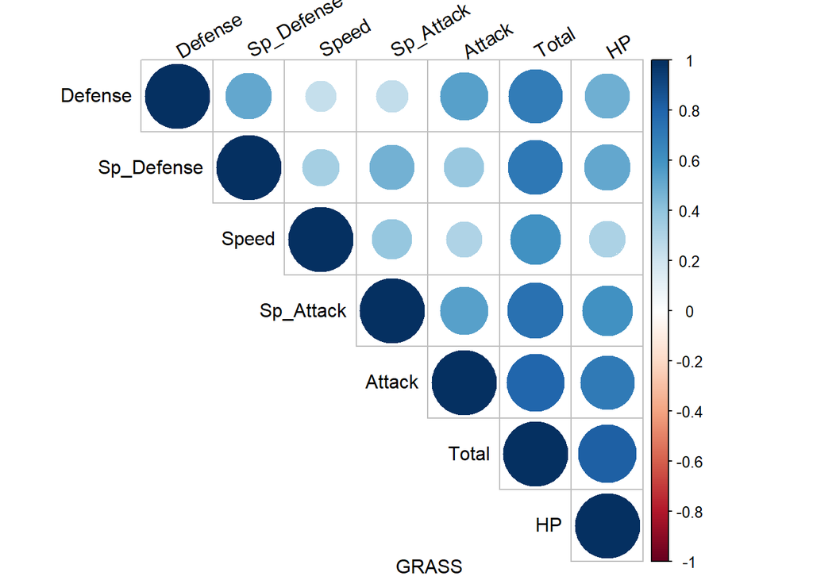

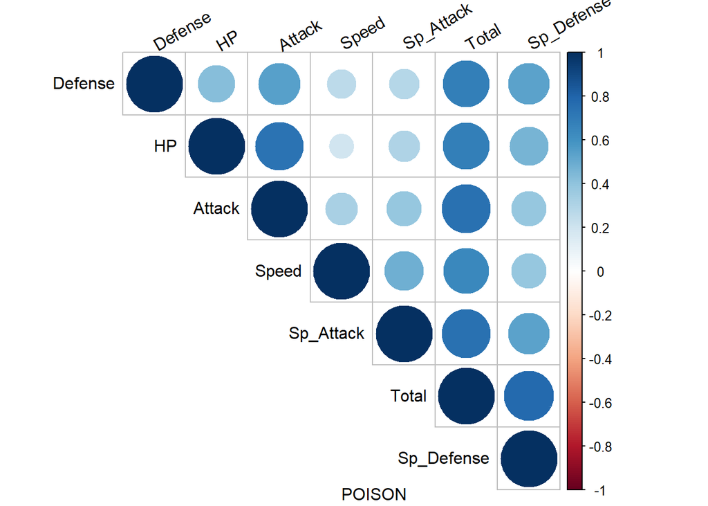

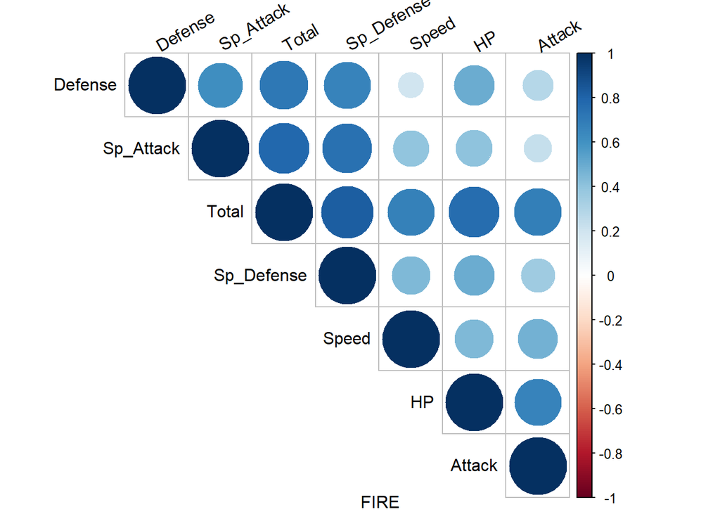

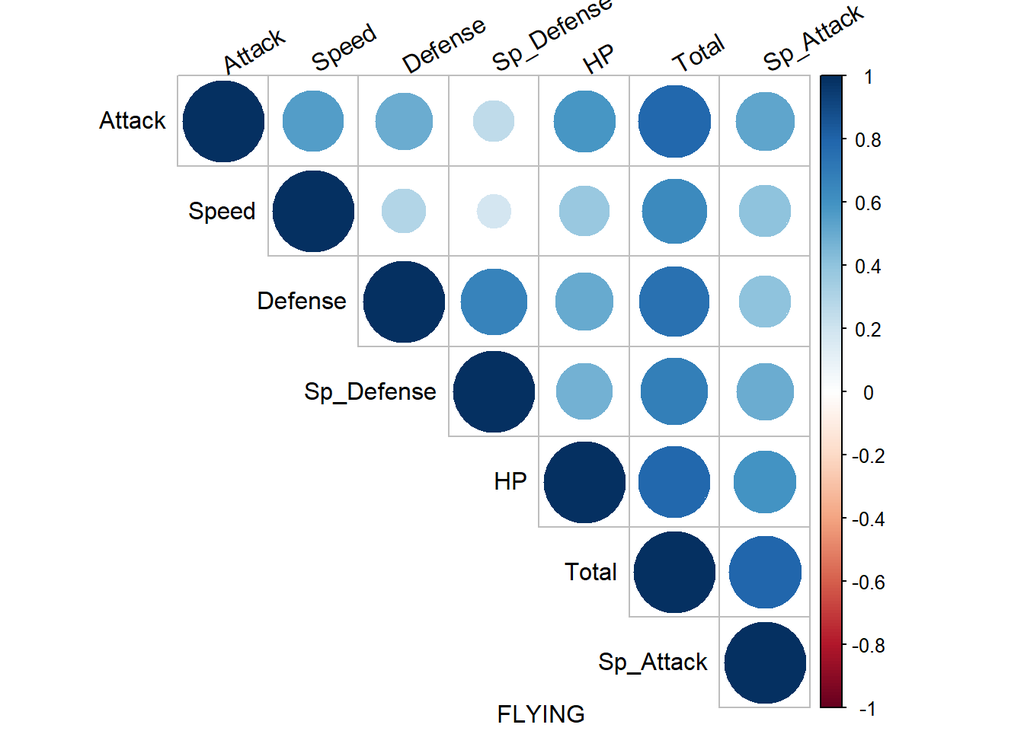

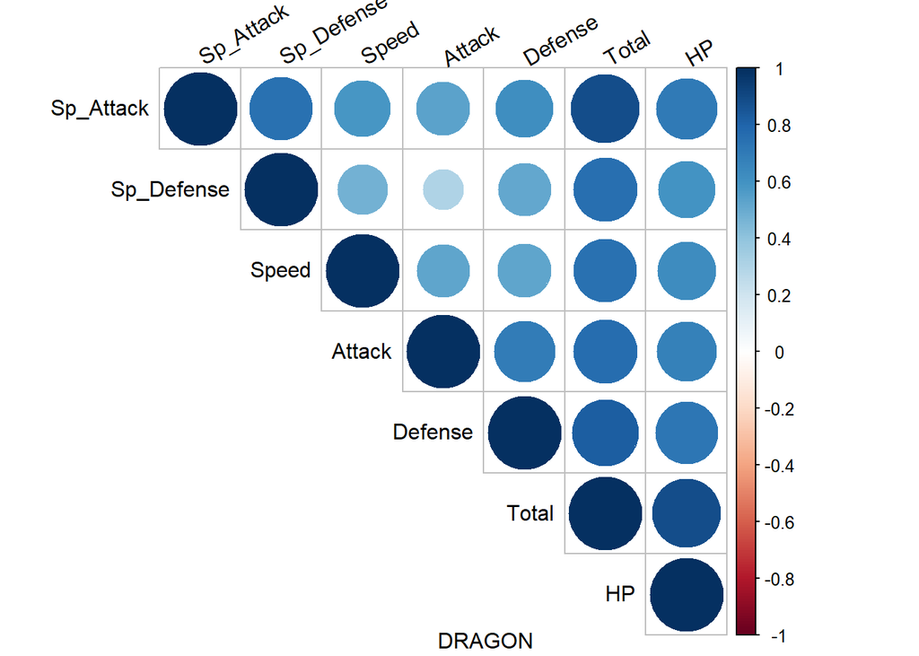

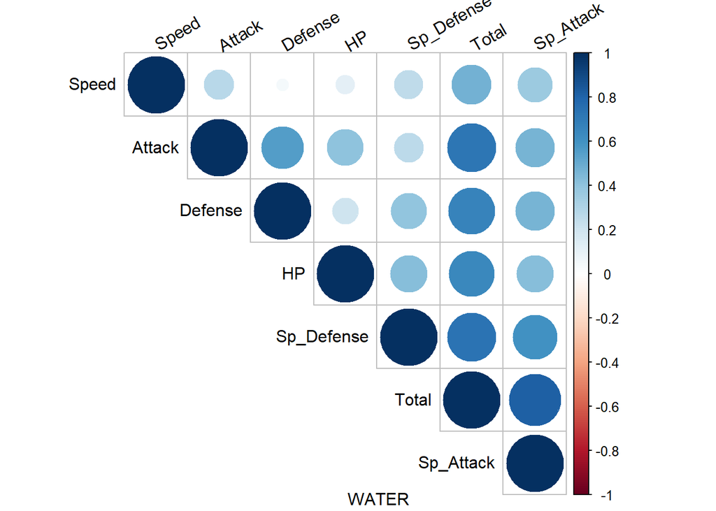

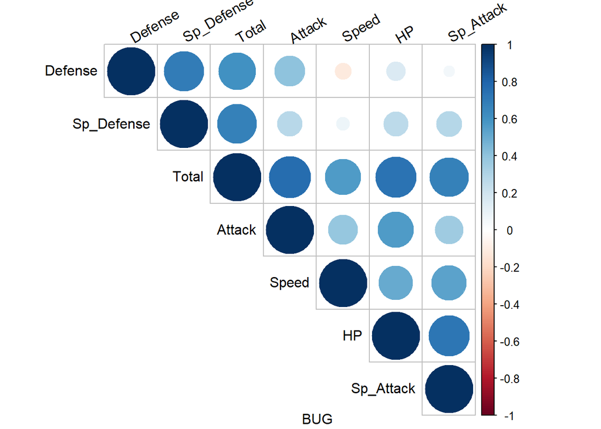

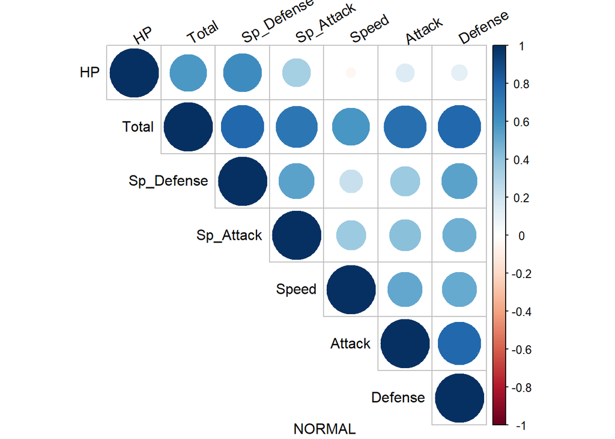

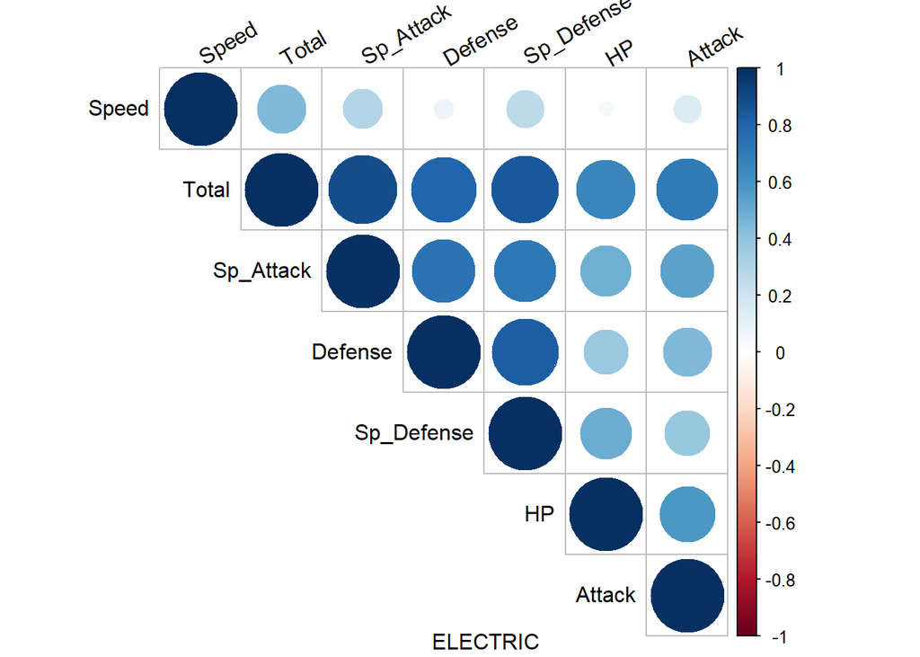

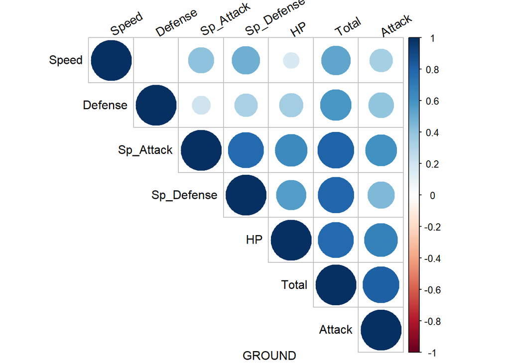

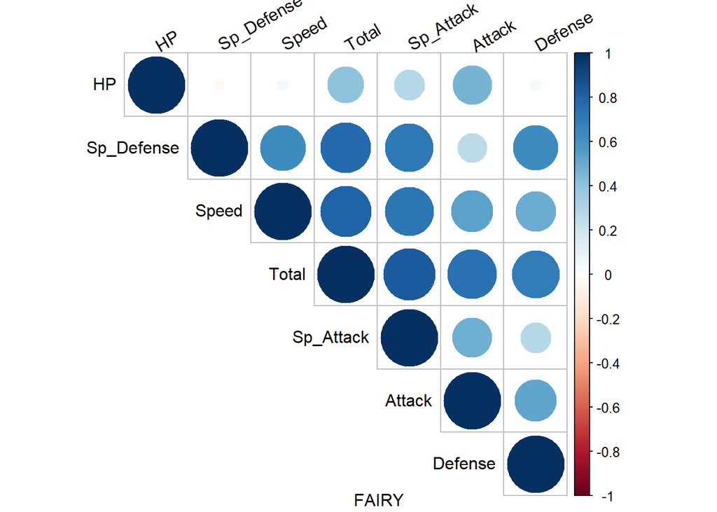

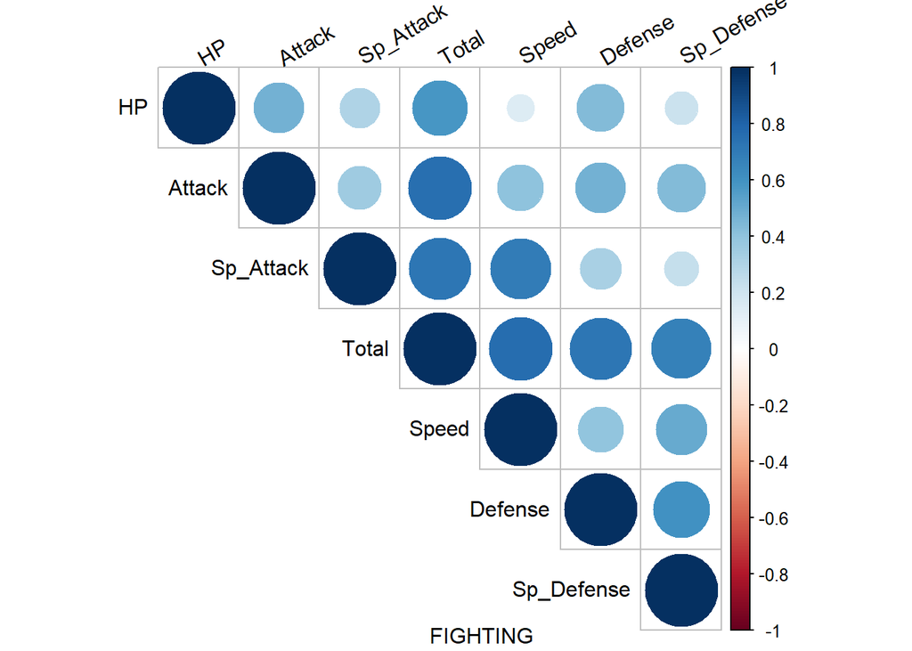

[6 more figures not shown]

Llaman la atención los Pokémon de tipo “ROCK” que tienen atributos correlacionados de forma negativa. Visualicémoslos.

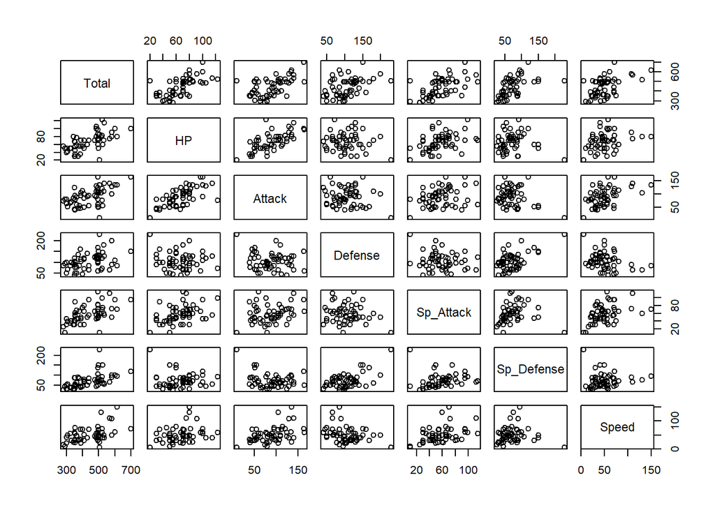

En concreto, Speed y Defense

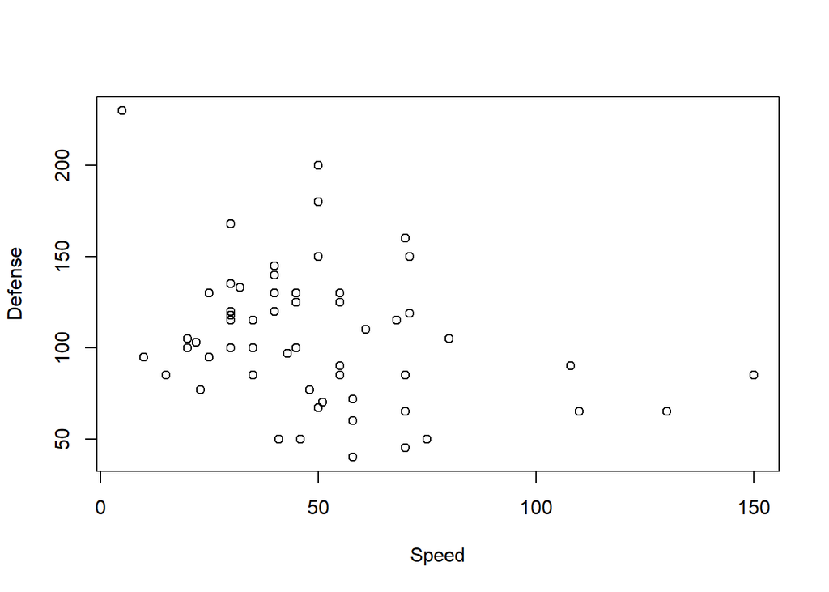

## Conclusiones

Después del estudio de los datos que nos aportan los atributos básicos de los Pokémon, podemos concluir que no se obtienen datos significativos que permitan decidir qué Pokémon es mejor a utilizar en las batallas o enfrentamientos, salvo los mencionados para el tipo “ROCK” pero que no consideramos relevante como para decidir un combate.

Es necesario analizar el resto de los atributos de los Pokémon y el efecto que tienen los objetos que se pueden conseguir en el juego para definir una estrategia adecuada en el desarrollo del juego, sobre todo para los combates con los adversarios más fuertes (jefes de gimnasio) que tienen los Pokémon más desarrollados.

## Refencias

Sanchez-Ante, Gildardo. 2013. *Sistemas Inteligentes: Reportes Finales Ago-Dic 2013*.

(@steveinatx), Steve Burger. 2016. “Www.data.world/Steveinatx/Pokemon-Index.”